# Stat 430 Project

Maxx Wayne

# Introduction

My Project will be using Principal Component Analysis to analyze NBA statistics from 1980-2017. I retrieved the data set from a csv file from kaggle: “https://www.kaggle.com/drgilermo/nba-players-stats/version/2#Seasons_Stats.csv”. I chose 1980 as the first year, rather than choosing all years in the original data set, because the three point line was established in 1980, therefore the statistics from the earlier seasons may skew the data. I want to study which statistics have the biggest impact on the component scores, to determine who has had the best indivdual NBA season from 1980-2017. The data set contains every statistic kept by the NBA, but I will only be analyzing those that are % based because I believe those show a players true impact on the game. For example, I will not be including total rebounds or assists, but instead I will be using offensive rebounding %, defensive rebounding %, and assist %, which gives a better representation of a players impact. I will be using the following statistics: true shooting % (which accounts for field goals and free throws), offensive rebounding %, defensive rebounding %, assist %, steal %, block %, usage % (a metric that determines what percentage of plays a player alters the game in some way), box plus/minus (the change in score of the game while the player is on the court), 3 point field goal %, 2 point field goal %, free throw %, and points per minute, which is a statistic I created. I then normalized all of the statistics so they had equal variation and means, so one statistic does not carry too much weight. I will also be using Player Efficency Rating (PER) which is the most common basketball metric to determine a players impact on the game. I will see how PER relates to each component and the total scores, to see if the components are a better predictor of PER than the statistics are.

# Methods

I will start by selecting only the observations starting in 1980. Then I will subset the qualitative statistcs (Year, Player Name, Position, Age, and Team) I will be keeping into one data set named qualitative_stats. I will create a new variable called PPM which stands for Points per Minute, by Dividing Points (PTS) by Minutes (MP). I will be subsetting the 12 quantitative statistics I am keeping into a data set named quantitative_stats. There are some blank and N/A observations that I will be omitting from these two data sets. I will then normalize all 12 quantiative statistics to ensure one does not skew the data and bind them into a new data set qualitative_stats_norm. I will inspect the correlation matrix and extract the eigenvalues to better understand each statistic. I will also inspect the correlation between PER and each component to see how they are related. By Using the summary function I will see which components account for the most variation and I will only keep the amount of components that make for 90% of the variation. Once I know which components account for 90% of the variation, I will observe the loadings of each component, which will tell me what each component is made up of. I will then analyze what indivdual player seasons, using the dplyr package, to see which indivudal seasons were the best by certain components and total scores. I will also plot Standarized PER vs each component, total scores, and some combinations of components to determine correlations and get a better understanding of which components are positive or negative. I will divide half of the data into a training set randomly. Then, I will then use lm() to see if the components are a better predictor for Standarized PER than the standarized statistics. I will use the summary function to observe the regression coefficients and residual standard errors. These are the methods I will be using.

# Analysis

### **Arranging the Data Sets**

```r
basketball=read.csv('C:/Users/maxxb/Documents/430/basketball.csv',header=TRUE)
bball=na.omit(basketball[c(5728:24692),c(2:7,9:21,23:26,28:53),])
qualitative_stats=bball[,c(1:5)]
PPM=bball$PTS/bball$MP
quantitative_stats=cbind(bball[,c(9,12:13,15:17,19,26,33,36,40)],PPM)
```

### **Standardizing the Data**

```r
TS._norm=(quantitative_stats$TS.-mean(quantitative_stats$TS.))/sd(quantitative_stats$TS.)
ORB._norm=(quantitative_stats$ORB.-mean(quantitative_stats$ORB.))/sd(quantitative_stats$ORB.)
DRB._norm=(quantitative_stats$DRB.-mean(quantitative_stats$DRB.))/sd(quantitative_stats$DRB.)
AST._norm=(quantitative_stats$AST.-mean(quantitative_stats$AST.))/sd(quantitative_stats$AST.)
STL._norm=(quantitative_stats$STL.-mean(quantitative_stats$STL.))/sd(quantitative_stats$STL.)
BLK._norm=(quantitative_stats$BLK.-mean(quantitative_stats$BLK.))/sd(quantitative_stats$BLK.)
USG._norm=(quantitative_stats$USG.-mean(quantitative_stats$USG.))/sd(quantitative_stats$USG.)
BPM_norm=(quantitative_stats$BPM-mean(quantitative_stats$BPM))/sd(quantitative_stats$BPM)
X3P._norm=(quantitative_stats$X3P.-mean(quantitative_stats$X3P.))/sd(quantitative_stats$X3P.)
X2P._norm=(quantitative_stats$X2P.-mean(quantitative_stats$X2P.))/sd(quantitative_stats$X2P.)
FT._norm=(quantitative_stats$FT.-mean(quantitative_stats$FT.))/sd(quantitative_stats$FT.)
PPM_norm=(quantitative_stats$PPM-mean(quantitative_stats$PPM))/sd(quantitative_stats$PPM)

PER_norm=(bball$PER-mean(bball$PER))/sd(bball$PER)

quantitative_stats_norm=cbind(TS._norm,ORB._norm,DRB._norm,AST._norm,STL._norm,BLK._norm,USG._norm,BPM_norm,X3P._norm,X2P._norm,FT._norm,PPM_norm)
```

### **Principal Components**

```r
library(stats)
round(cor(quantitative_stats_norm),4)
```

```
##           TS._norm ORB._norm DRB._norm AST._norm STL._norm BLK._norm USG._norm
## TS._norm    1.0000    0.0593    0.1203    0.0260   -0.0616    0.0901    0.0788
## ORB._norm   0.0593    1.0000    0.6568   -0.5025   -0.1702    0.5100   -0.0326
## DRB._norm   0.1203    0.6568    1.0000   -0.4191   -0.2340    0.5766   -0.0231
## AST._norm   0.0260   -0.5025   -0.4191    1.0000    0.3687   -0.3882    0.2287
## STL._norm  -0.0616   -0.1702   -0.2340    0.3687    1.0000   -0.1591    0.0653
## BLK._norm   0.0901    0.5100    0.5766   -0.3882   -0.1591    1.0000   -0.0578
## USG._norm   0.0788   -0.0326   -0.0231    0.2287    0.0653   -0.0578    1.0000
## BPM_norm    0.6647    0.1364    0.2287    0.2140    0.2679    0.2066    0.1100
## X3P._norm   0.2117   -0.3921   -0.2516    0.1969    0.0548   -0.2438    0.0887
## X2P._norm   0.7448    0.2109    0.2003   -0.0486   -0.0541    0.1890    0.0169
## FT._norm    0.3104   -0.3222   -0.2298    0.2217    0.0058   -0.2606    0.1883
## PPM_norm    0.4765    0.0191    0.0254    0.1422    0.0022   -0.0159    0.8702
##           BPM_norm X3P._norm X2P._norm FT._norm PPM_norm
## TS._norm    0.6647    0.2117    0.7448   0.3104   0.4765
## ORB._norm   0.1364   -0.3921    0.2109  -0.3222   0.0191
## DRB._norm   0.2287   -0.2516    0.2003  -0.2298   0.0254
## AST._norm   0.2140    0.1969   -0.0486   0.2217   0.1422
## STL._norm   0.2679    0.0548   -0.0541   0.0058   0.0022
## BLK._norm   0.2066   -0.2438    0.1890  -0.2606  -0.0159
## USG._norm   0.1100    0.0887    0.0169   0.1883   0.8702
## BPM_norm    1.0000    0.1463    0.5185   0.1816   0.4118
## X3P._norm   0.1463    1.0000   -0.0747   0.2139   0.1400
## X2P._norm   0.5185   -0.0747    1.0000   0.0131   0.3316
## FT._norm    0.1816    0.2139    0.0131   1.0000   0.2986
## PPM_norm    0.4118    0.1400    0.3316   0.2986   1.0000
```

```r
eigen(cor(quantitative_stats_norm))$values
```

```
##  [1] 3.08058535 2.96009787 1.44235515 1.20609852 0.83241828 0.72629272
##  [7] 0.55776996 0.47094807 0.29041375 0.26016874 0.14444694 0.02840465
```

```r
round(cor(cbind(quantitative_stats_norm,PER_norm)),4)[13,]
```

```
##  TS._norm ORB._norm DRB._norm AST._norm STL._norm BLK._norm USG._norm  BPM_norm
##    0.7005    0.1876    0.2507    0.2683    0.1609    0.1948    0.5012    0.8048
## X3P._norm X2P._norm  FT._norm  PPM_norm  PER_norm
##    0.1127    0.5444    0.2584    0.7576    1.0000
```

```r
PC=princomp(quantitative_stats_norm,scores=TRUE,cor=TRUE)
summary(PC)
```

```
## Importance of components:
##                           Comp.1    Comp.2    Comp.3    Comp.4     Comp.5
## Standard deviation     1.7551596 1.7204935 1.2009809 1.0982252 0.91236960
## Proportion of Variance 0.2567154 0.2466748 0.1201963 0.1005082 0.06936819
## Cumulative Proportion  0.2567154 0.5033903 0.6235865 0.7240947 0.79346293
##                            Comp.6     Comp.7     Comp.8     Comp.9    Comp.10
## Standard deviation     0.85222809 0.74683998 0.68625657 0.53890050 0.51006738
## Proportion of Variance 0.06052439 0.04648083 0.03924567 0.02420115 0.02168073
## Cumulative Proportion  0.85398732 0.90046815 0.93971383 0.96391497 0.98559570
##                           Comp.11     Comp.12
## Standard deviation     0.38006176 0.168536777
## Proportion of Variance 0.01203724 0.002367054
## Cumulative Proportion  0.99763295 1.000000000
```

```r
round(PC$loadings[,1:7],4)
```

```
##            Comp.1 Comp.2  Comp.3  Comp.4  Comp.5  Comp.6  Comp.7
## TS._norm   0.0155 0.4921  0.2978  0.2219  0.0828  0.0780  0.0701
## ORB._norm  0.4678 0.0843 -0.1253 -0.1358  0.0036 -0.0732  0.2785
## DRB._norm  0.4469 0.1291 -0.0864 -0.0562 -0.2452 -0.2228 -0.1618
## AST._norm -0.3978 0.0815  0.0746 -0.3482  0.0898 -0.0031 -0.6742
## STL._norm -0.2054 0.0334  0.1747 -0.7165 -0.1129 -0.1458  0.4966
## BLK._norm  0.4158 0.1012 -0.0286 -0.1210 -0.2918 -0.1729 -0.3909
## USG._norm -0.1547 0.2793 -0.6717 -0.1244 -0.0311  0.1099 -0.0022
## BPM_norm   0.0205 0.4586  0.2829 -0.2516 -0.1764 -0.1586 -0.0904
## X3P._norm -0.2781 0.1013  0.1313  0.2834 -0.8043  0.2287  0.1038
## X2P._norm  0.1426 0.4142  0.2972  0.0577  0.3638  0.3518  0.0258
## FT._norm  -0.2706 0.1973 -0.0085  0.3426  0.1222 -0.8131  0.0938
## PPM_norm  -0.1127 0.4550 -0.4631  0.0087  0.0284  0.1159  0.0949
```

### **Visualization Analysis**

```r
library(dplyr)
scores=data.frame(PC$scores[,1:7])
scores$total=scores$Comp.1+scores$Comp.2+scores$Comp.3+scores$Comp.4+scores$Comp.5+scores$Comp.6+scores$Comp.7
all=cbind(qualitative_stats,scores)

all %>% select(Year,Player,Pos,Age,Tm,Comp.1,total) %>% top_n(20,Comp.1)
```

```
##    Year            Player Pos Age  Tm   Comp.1       total
## 1  1986        Manute Bol   C  23 WSB 5.896762  0.31363999
## 2  1988        Manute Bol   C  25 WSB 6.013159  0.09010738
## 3  1988 Granville Waiters   C  27 CHI 5.859393 -4.74962922
## 4  2000     Greg Ostertag   C  26 UTA 5.816866  2.10555527
## 5  2002       Ben Wallace   C  27 DET 5.819383  3.22568233
## 6  2003       Ben Wallace   C  28 DET 5.614927  1.19362857
## 7  2006  Alonzo Mourning*   C  35 MIA 6.167841  5.94257157
## 8  2006       Loren Woods   C  27 TOR 5.867608  2.78338531
## 9  2007     Jamal Sampson   C  23 DEN 5.863048 10.30838706
## 10 2009  Shavlik Randolph  PF  25 POR 5.715908  9.83351194
## 11 2011     Hamed Haddadi   C  25 MEM 5.839695  3.58828398
## 12 2012     Hamed Haddadi   C  26 MEM 6.626045  3.85454871
## 13 2012    DeAndre Jordan   C  23 LAC 5.713185  9.05349974
## 14 2015    Andre Drummond   C  21 DET 5.751236  3.45901946
## 15 2015       Rudy Gobert   C  22 UTA 5.622863  6.53599920
## 16 2015    DeAndre Jordan   C  26 LAC 6.303154 10.87902140
## 17 2016   Bismack Biyombo   C  23 TOR 5.681136  5.62220850
## 18 2016    DeAndre Jordan   C  27 LAC 5.961863  9.89232915
## 19 2017       Rudy Gobert   C  24 UTA 5.696676  9.38996578
## 20 2017    DeAndre Jordan   C  28 LAC 5.900466 11.54160331
```

```r
all %>% select(Year,Player,Pos,Age,Tm,Comp.2,total) %>% top_n(20,Comp.2)
```

```
##    Year            Player Pos Age  Tm    Comp.2      total
## 1  1988   Michael Jordan*  SG  24 CHI  5.939015 -0.6138025
## 2  1989   Michael Jordan*  SG  25 CHI  6.012267 -0.7452591
## 3  1990   Michael Jordan*  SG  26 CHI  5.898413 -0.4390082
## 4  1991   Michael Jordan*  SG  27 CHI  5.793255 -0.1774246
## 5  1991     Howard Wright  PF  23 DAL  8.121139 18.3550430
## 6  1995 Darrell Armstrong  PG  26 ORL 11.537555 -9.5644860
## 7  1995     Elmer Bennett  PG  24 CLE  7.006788 -5.8716051
## 8  1996 Darrell Armstrong  PG  27 ORL  6.481843 -5.5102335
## 9  1999    Korleone Young  SF  20 DET  6.292445  6.4879039
## 10 2004   Chris Jefferies  SG  23 TOR  7.641280  0.9201131
## 11 2006      Amir Johnson  SF  18 DET  5.670123 12.6313359
## 12 2009      LeBron James  SF  24 CLE  5.685733 -2.1552136
## 13 2010      LeBron James  SF  25 CLE  5.802266 -1.6084547
## 14 2011   Peja Stojakovic  SF  33 TOR  8.338242 14.6005040
## 15 2013      LeBron James  PF  28 MIA  5.873006  1.0607406
## 16 2014      Kevin Durant  SF  25 OKC  5.723851  0.7081920
## 17 2016     Stephen Curry  PG  27 GSW  6.752413  0.8106531
## 18 2017      Kevin Durant  SF  28 GSW  5.731059  2.5035663
## 19 2017      James Harden  PG  27 HOU  5.763598 -3.1221471
## 20 2017 Russell Westbrook  PG  28 OKC  6.752314 -7.5948196
```

```r
all %>% select(Year,Player,Pos,Age,Tm,Comp.1,Comp.2,total) %>% top_n(20,Comp.1+Comp.2)
```

```
##    Year            Player Pos Age  Tm   Comp.1   Comp.2     total
## 1  1990   David Robinson*   C  24 SAS 3.654515 4.186432  2.232594
## 2  1991   David Robinson*   C  25 SAS 3.375878 4.893713  2.965043
## 3  1991     Howard Wright  PF  23 DAL 0.894312 8.121139 18.355043
## 4  1992   David Robinson*   C  26 SAS 3.509005 4.598677  1.696995
## 5  1993 Shaquille O'Neal*   C  20 ORL 4.491055 3.505941  4.084316
## 6  1994 Shaquille O'Neal*   C  21 ORL 3.700613 4.636878  5.554418
## 7  1995 Shaquille O'Neal*   C  22 ORL 3.252865 4.578207  4.289848
## 8  2000 Shaquille O'Neal*   C  27 LAL 3.534922 4.867854  3.025518
## 9  2006  Alonzo Mourning*   C  35 MIA 6.167841 2.234890  5.942572
## 10 2009     Dwight Howard   C  23 ORL 4.835214 3.660899  4.525646
## 11 2010     Dwight Howard   C  24 ORL 4.942218 4.003654  5.875735
## 12 2011     Dwight Howard   C  25 ORL 4.335144 4.102555  5.240243
## 13 2012     Hamed Haddadi   C  26 MEM 6.626045 1.957406  3.854549
## 14 2015       Rudy Gobert   C  22 UTA 5.622863 2.677813  6.535999
## 15 2015    DeAndre Jordan   C  26 LAC 6.303154 2.986545 10.879021
## 16 2016    DeAndre Jordan   C  27 LAC 5.961863 2.829674  9.892329
## 17 2017       Rudy Gobert   C  24 UTA 5.696676 3.938058  9.389966
## 18 2017     Dwight Howard   C  31 ATL 5.002180 2.915334  8.211293
## 19 2017    DeAndre Jordan   C  28 LAC 5.900466 3.500813 11.541603
## 20 2017      JaVale McGee   C  29 GSW 5.292425 3.874765  8.600221
```

```r
all %>% select(Year,Player,Pos,Age,Tm,Comp.4,total) %>% top_n(20,Comp.4)
```

```
##    Year                Player Pos Age  Tm   Comp.4        total
## 1  1984         Roger Phegley  SG  27 SAS 3.905143 -1.037655727
## 2  1991        Scott Hastings  PF  30 DET 3.681942  8.274104201
## 3  1992           Travis Mays  PG  23 ATL 3.783364  0.442908736
## 4  1994           Todd Lichti  SG  27 GSW 3.392116 -3.613890573
## 5  1997 Aleksandar Djordjevic  SG  29 POR 3.517480  1.305715166
## 6  1997           Kenny Smith  PG  31 ORL 3.953442 -0.004506356
## 7  1998             Tony Delk  PG  24 CHH 4.356265 12.199258274
## 8  1999          Sam Jacobson  PG  23 LAL 3.928710 10.972052023
## 9  2003      Anthony Goldwire  PG  31 WAS 4.837635  5.571017168
## 10 2004          Matt Carroll  SG  23 POR 3.936367  3.534502377
## 11 2004        Maurice Carter  SG  27 LAL 3.463121 -0.211945876
## 12 2004            Josh Davis  PF  23 ATL 3.490688  6.504447431
## 13 2004            Dan Langhi  SF  26 TOT 4.030656 -3.440456783
## 14 2006          Amir Johnson  SF  18 DET 3.806768 12.631335896
## 15 2011           Steve Novak  SF  27 TOT 3.826271  4.995233566
## 16 2011           Steve Novak  SF  27 SAS 3.730755  6.163883471
## 17 2011       Peja Stojakovic  SF  33 TOR 4.477440 14.600503989
## 18 2016           Steve Novak  PF  32 TOT 4.211941  1.441077605
## 19 2017        Archie Goodwin  SG  22 NOP 4.251536  3.877753040
## 20 2017          John Jenkins  SG  25 PHO 3.503498 -0.955301826
```

```r
all %>% select(Year,Player,Pos,Age,Tm,Comp.3,Comp.4,total) %>% top_n(20,Comp.3+Comp.4)
```

```
##    Year           Player Pos Age  Tm    Comp.3    Comp.4     total
## 1  1985   George Johnson   C  36 NJN 3.5671879 2.3149251  3.829365
## 2  1991   Scott Hastings  PF  30 DET 1.5341932 3.6819419  8.274104
## 3  1993      Matt Othick  PG  23 SAS 5.0774612 0.2112022 17.825805
## 4  1995      Danny Young  PG  32 MIL 4.2091001 1.1318427  9.596061
## 5  1998        Tony Delk  PG  24 CHH 3.9382938 4.3562654 12.199258
## 6  2000    Kevin Johnson  PG  33 PHO 2.4643954 2.9259808  1.384694
## 7  2003 Anthony Goldwire  PG  31 WAS 1.0686344 4.8376350  5.571017
## 8  2006     Amir Johnson  SF  18 DET 2.4163524 3.8067685 12.631336
## 9  2011    Jason Collins   C  32 ATL 2.5374494 2.6409561  2.693094
## 10 2011  Antonio Daniels  PG  35 PHI 2.3061077 3.0831363  6.776672
## 11 2011      Steve Novak  SF  27 SAS 1.4878198 3.7307548  6.163883
## 12 2011  Peja Stojakovic  SF  33 TOR 0.6796003 4.4774404 14.600504
## 13 2014   Othyus Jeffers  SG  28 TOT 2.9362678 2.7531844 11.809265
## 14 2014   Othyus Jeffers  SG  28 SAS 3.2632230 1.9010532 13.008940
## 15 2014   Cartier Martin  SF  29 CHI 3.9922781 2.2211380 12.606765
## 16 2016  Sean Kilpatrick  SG  26 DEN 3.0729747 2.3107055 15.179912
## 17 2016     Damjan Rudez  SF  29 MIN 2.2432393 3.3071354  7.739908
## 18 2017   Archie Goodwin  SG  22 NOP 1.2217646 4.2515363  3.877753
## 19 2017     Jarrett Jack  PG  33 NOP 5.6119035 1.5438593 16.885003
## 20 2017     Wayne Selden  SG  22 NOP 5.4365415 1.9651977 20.729869
```

```r
all %>% select(Year,Player,Pos,Age,Tm,Comp.5,total) %>% top_n(20,Comp.5)
```

```
##    Year           Player Pos Age  Tm   Comp.5     total
## 1  1990     Wes Matthews  PG  30 ATL 3.670878 -2.081351
## 2  1991    Howard Wright  PF  23 DAL 3.616329 18.355043
## 3  1995      Tate George  SG  26 MIL 3.341569  3.695534
## 4  1998      Greg Graham  SG  27 CLE 4.514450  8.927316
## 5  1998 Donald Whiteside  PG  28 ATL 4.090561 13.740184
## 6  1999 Jerald Honeycutt  PF  24 MIL 3.768758 10.643035
## 7  1999     Sam Jacobson  PG  23 LAL 3.318859 10.972052
## 8  1999    Adonis Jordan  PG  28 MIL 3.651173  7.659208
## 9  1999     Doug Overton  PG  29 ORL 3.037699  4.665003
## 10 2002     Charlie Bell  SG  22 PHO 3.110660  1.842519
## 11 2004       Josh Davis  PF  23 ATL 3.137976  6.504447
## 12 2005  Michael Bradley  PF  25 PHI 4.213820 19.417651
## 13 2008       Mike Wilks  PG  28 SEA 3.352467  1.045089
## 14 2013    Scott Machado  PG  22 HOU 3.258307 -3.109695
## 15 2013     Brandon Rush  SF  27 GSW 4.493861 13.562265
## 16 2014 Jared Cunningham  SG  22 ATL 4.392663 12.653988
## 17 2014   Othyus Jeffers  SG  28 TOT 3.080989 11.809265
## 18 2016  Jorge Gutierrez  PG  27 CHO 3.150899  4.739541
## 19 2016  Sean Kilpatrick  SG  26 DEN 3.736975 15.179912
## 20 2017     Jarrett Jack  PG  33 NOP 5.613989 16.885003
```

```r
all %>% select(Year,Player,Pos,Age,Tm,Comp.6,total) %>% top_n(20,Comp.6)
```

```
##    Year           Player   Pos Age  Tm   Comp.6      total
## 1  1988     Mike O'Koren    SF  29 NJN 4.982232  5.8462474
## 2  1989    Otis Birdsong    SG  33 BOS 5.635686  3.6552730
## 3  1989     Sedric Toney    PG  26 IND 6.044765 -1.5626674
## 4  1993      Matt Othick    PG  23 SAS 8.495566 17.8258045
## 5  1997 Haywoode Workman    PG  31 IND 5.631885  7.1950138
## 6  1998       Tony Dumas    SG  25 CLE 6.096143  3.4874299
## 7  1998 Donald Whiteside    PG  28 ATL 7.683209 13.7401840
## 8  2004 Desmond Ferguson    SF  26 POR 5.951918  4.1478288
## 9  2005 Tremaine Fowlkes    SF  28 IND 5.999255  6.8898962
## 10 2008     Richie Frahm    SG  30 LAC 5.421768  1.7625608
## 11 2008   Thomas Gardner    SG  22 CHI 6.641869  4.8083476
## 12 2008  DerMarr Johnson    SF  27 SAS 7.543635 11.2866127
## 13 2010      Will Conroy    PG  27 HOU 5.038162 -4.3502078
## 14 2011       John Lucas    PG  28 CHI 5.865043 -1.0078903
## 15 2014 Jared Cunningham    SG  22 ATL 7.813860 12.6539884
## 16 2014       A.J. Price    SG  27 MIN 6.091645  2.2739831
## 17 2015      Steve Novak SF-PF  31 TOT 5.027332  2.5366983
## 18 2017       Quinn Cook    PG  23 DAL 6.452971  2.8107710
## 19 2017   Tim Quarterman    SG  22 POR 5.212401  0.9908088
## 20 2017     Wayne Selden    SG  22 NOP 5.066478 20.7298689
```

```r
all %>% select(Year,Player,Pos,Age,Tm,Comp.5,Comp.6,total) %>% top_n(20,Comp.5+Comp.6)
```

```
##    Year           Player Pos Age  Tm    Comp.5   Comp.6     total
## 1  1989     Sedric Toney  PG  26 IND 1.8576186 6.044765 -1.562667
## 2  1993      Matt Othick  PG  23 SAS 2.1601027 8.495566 17.825805
## 3  1997 Haywoode Workman  PG  31 IND 2.1053097 5.631885  7.195014
## 4  1998 Donald Whiteside  PG  28 ATL 4.0905606 7.683209 13.740184
## 5  1999 Jerald Honeycutt  PF  24 MIL 3.7687578 4.231529 10.643035
## 6  1999    Adonis Jordan  PG  28 MIL 3.6511730 3.383441  7.659208
## 7  2003 Ruben Wolkowyski  PF  29 BOS 2.8833930 4.786149  7.235193
## 8  2005  Michael Bradley  PF  25 PHI 4.2138199 4.653302 19.417651
## 9  2006     Reece Gaines  PG  25 MIL 2.6110633 4.459263  5.931259
## 10 2008   Thomas Gardner  SG  22 CHI 0.8955062 6.641869  4.808348
## 11 2008  DerMarr Johnson  SF  27 SAS 1.2102618 7.543635 11.286613
## 12 2010      Will Conroy  PG  27 HOU 1.3014432 5.038162 -4.350208
## 13 2011       John Lucas  PG  28 CHI 2.0480210 5.865043 -1.007890
## 14 2013     Brandon Rush  SF  27 GSW 4.4938607 3.750092 13.562265
## 15 2014      Vander Blue  SG  21 BOS 2.1239784 4.842395  4.323866
## 16 2014 Jared Cunningham  SG  22 ATL 4.3926630 7.813860 12.653988
## 17 2014       A.J. Price  SG  27 MIN 0.3613936 6.091645  2.273983
## 18 2017       Quinn Cook  PG  23 DAL 0.4327115 6.452971  2.810771
## 19 2017     Jarrett Jack  PG  33 NOP 5.6139886 1.442347 16.885003
## 20 2017     Wayne Selden  SG  22 NOP 1.6345223 5.066478 20.729869
```

```r
all %>% select(Year,Player,Pos,Age,Tm,total) %>% top_n(20,total)
```

```
##    Year           Player Pos Age  Tm    total
## 1  1991    Howard Wright  PF  23 DAL 18.35504
## 2  1992     Kenny Battle  SG  27 TOT 11.75942
## 3  1993      Matt Othick  PG  23 SAS 17.82580
## 4  1998        Tony Delk  PG  24 CHH 12.19926
## 5  1998 Donald Whiteside  PG  28 ATL 13.74018
## 6  2001    Carlos Rogers   C  29 HOU 12.11012
## 7  2005  Michael Bradley  PF  25 PHI 19.41765
## 8  2006     Amir Johnson  SF  18 DET 12.63134
## 9  2011  Peja Stojakovic  SF  33 TOR 14.60050
## 10 2012   Tyson Chandler   C  29 NYK 11.59048
## 11 2013     Brandon Rush  SF  27 GSW 13.56227
## 12 2013     Chris Wilcox   C  30 BOS 12.54374
## 13 2014 Jared Cunningham  SG  22 ATL 12.65399
## 14 2014   Othyus Jeffers  SG  28 TOT 11.80927
## 15 2014   Othyus Jeffers  SG  28 SAS 13.00894
## 16 2014   Cartier Martin  SF  29 CHI 12.60677
## 17 2016  Sean Kilpatrick  SG  26 DEN 15.17991
## 18 2017     Jarrett Jack  PG  33 NOP 16.88500
## 19 2017   DeAndre Jordan   C  28 LAC 11.54160
## 20 2017     Wayne Selden  SG  22 NOP 20.72987
```

```r
all %>% mutate(best=Comp.1+Comp.2+.5*Comp.3) %>% select(Year,Player,Pos,Age,Tm,best) %>% top_n(20,best)
```

```
##    Year           Player Pos Age  Tm      best
## 1  1991    Howard Wright  PF  23 DAL 10.429346
## 2  2006 Alonzo Mourning*   C  35 MIA  8.621038
## 3  2009   Chris Andersen   C  30 DEN  8.380618
## 4  2009   Joel Przybilla   C  29 POR  8.234518
## 5  2010    Dwight Howard   C  24 ORL  8.802545
## 6  2011   DeAndre Jordan   C  22 LAC  8.328224
## 7  2012   Tyson Chandler   C  29 NYK  8.564522
## 8  2012     Jeremy Evans  SF  24 UTA  9.039039
## 9  2012    Hamed Haddadi   C  26 MEM  8.618382
## 10 2012   DeAndre Jordan   C  23 LAC  8.188448
## 11 2014   Chris Andersen   C  35 MIA  8.511847
## 12 2015      Rudy Gobert   C  22 UTA  9.236697
## 13 2015   DeAndre Jordan   C  26 LAC 10.415563
## 14 2016   DeAndre Jordan   C  27 LAC  9.579735
## 15 2016      Salah Mejri   C  29 DAL  8.412324
## 16 2017      Rudy Gobert   C  24 UTA 10.356798
## 17 2017   DeAndre Jordan   C  28 LAC 10.273062
## 18 2017     JaVale McGee   C  29 GSW  8.719857
## 19 2017      Salah Mejri   C  30 DAL  8.394784
## 20 2017   Lucas Nogueira   C  24 TOR  8.850931
```

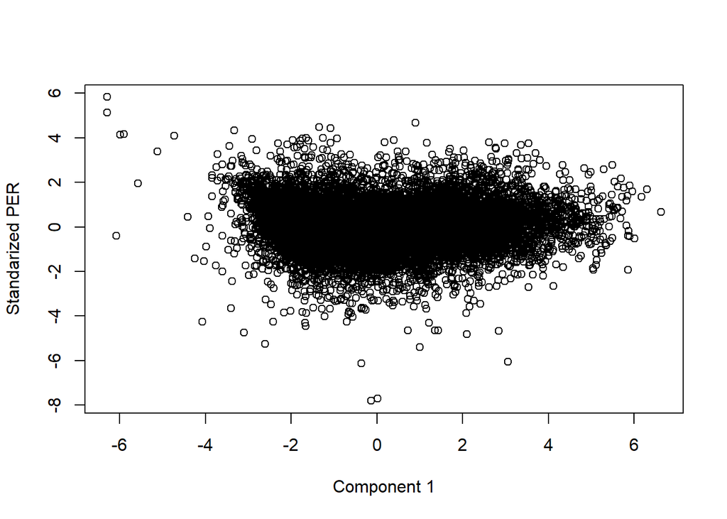

```r
plot(scores$Comp.1,PER_norm,xlab='Component 1',ylab='Standarized PER')
```

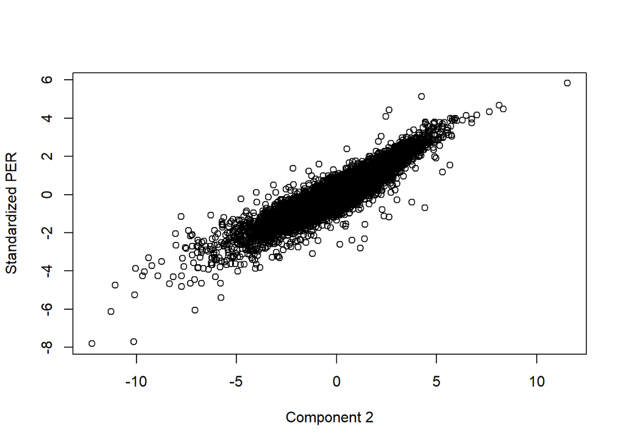

```r
plot(scores$Comp.2,PER_norm,xlab='Component 2',ylab='Standardized PER')
```

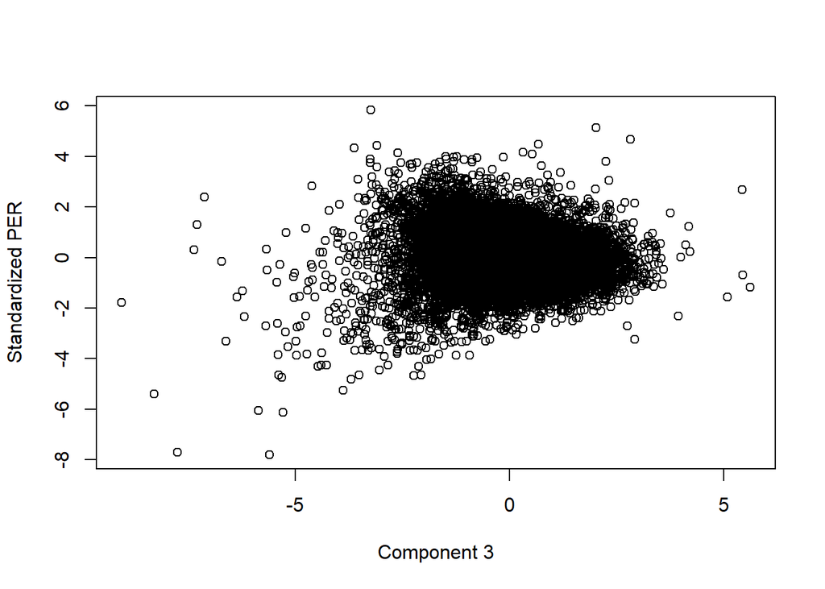

```r
plot(scores$Comp.3,PER_norm,xlab='Component 3',ylab='Standardized PER')
```

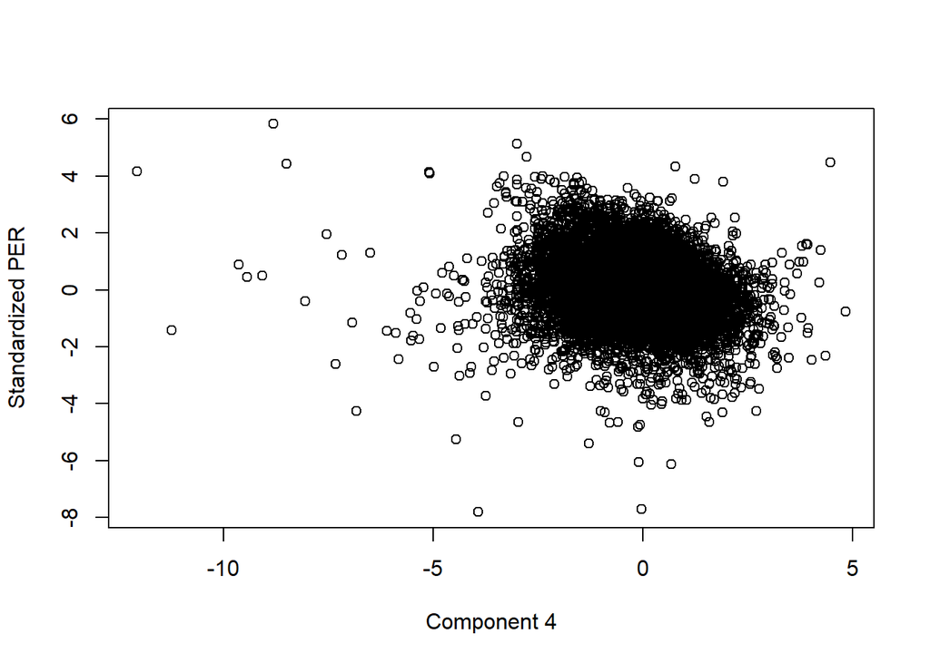

```r
plot(scores$Comp.4,PER_norm,xlab='Component 4',ylab='Standardized PER')
```

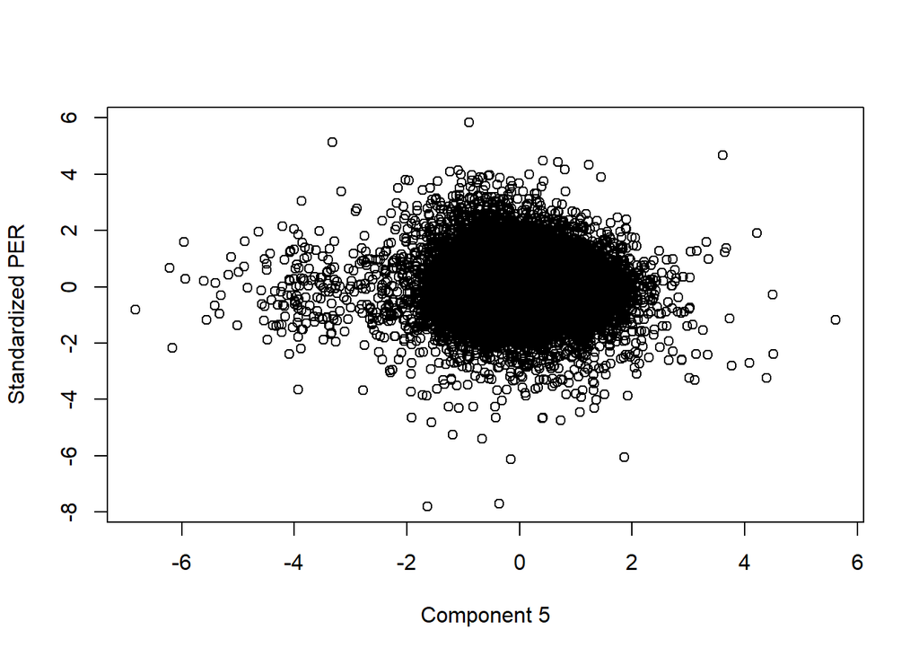

```r
plot(scores$Comp.5,PER_norm,xlab='Component 5',ylab='Standardized PER')
```

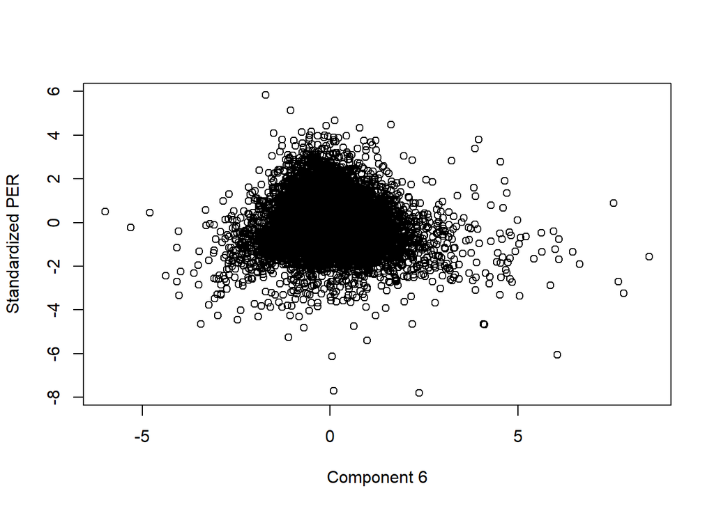

```r
plot(scores$Comp.6,PER_norm,xlab='Component 6',ylab='Standardized PER')
```

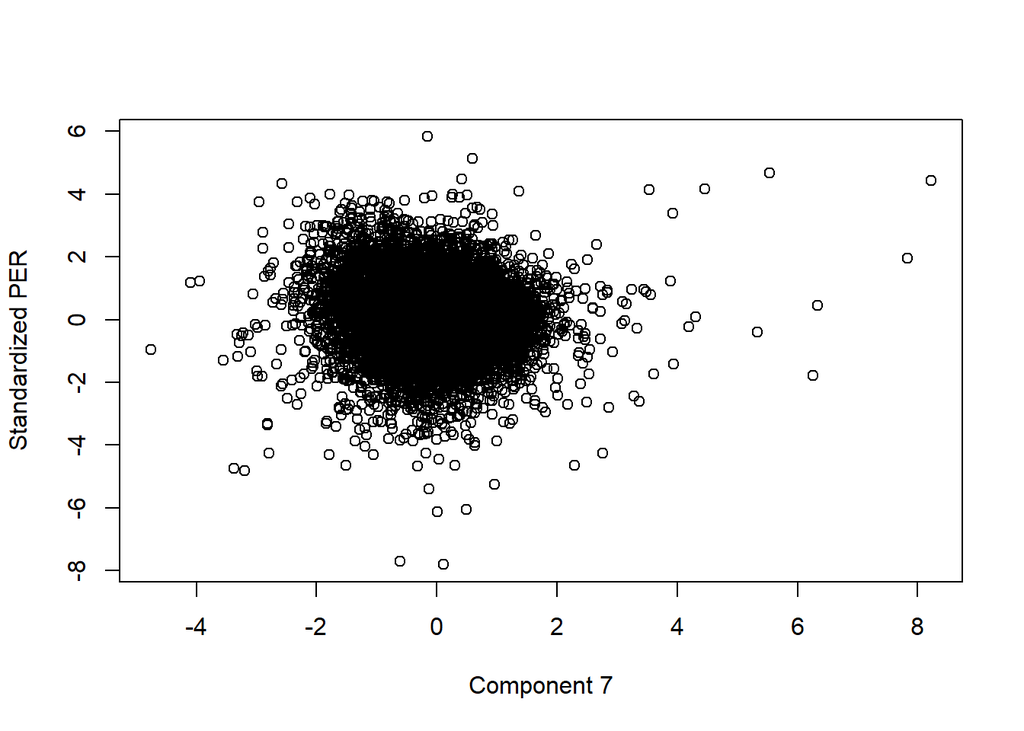

```r
plot(scores$Comp.7,PER_norm,xlab='Component 7',ylab='Standardized PER')
```

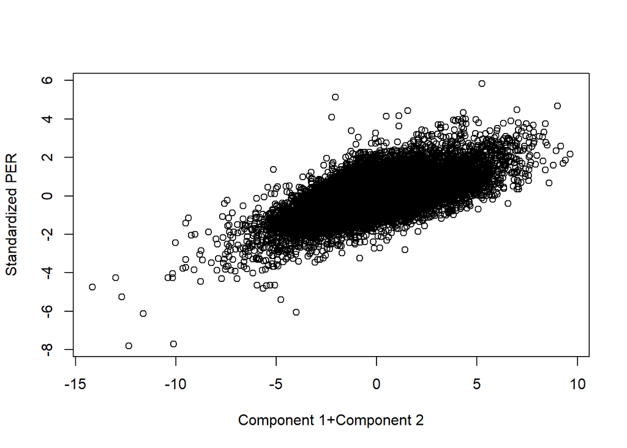

```r
plot(scores$Comp.1+scores$Comp.2,PER_norm,xlab='Component 1+Component 2',ylab='Standardized PER')
```

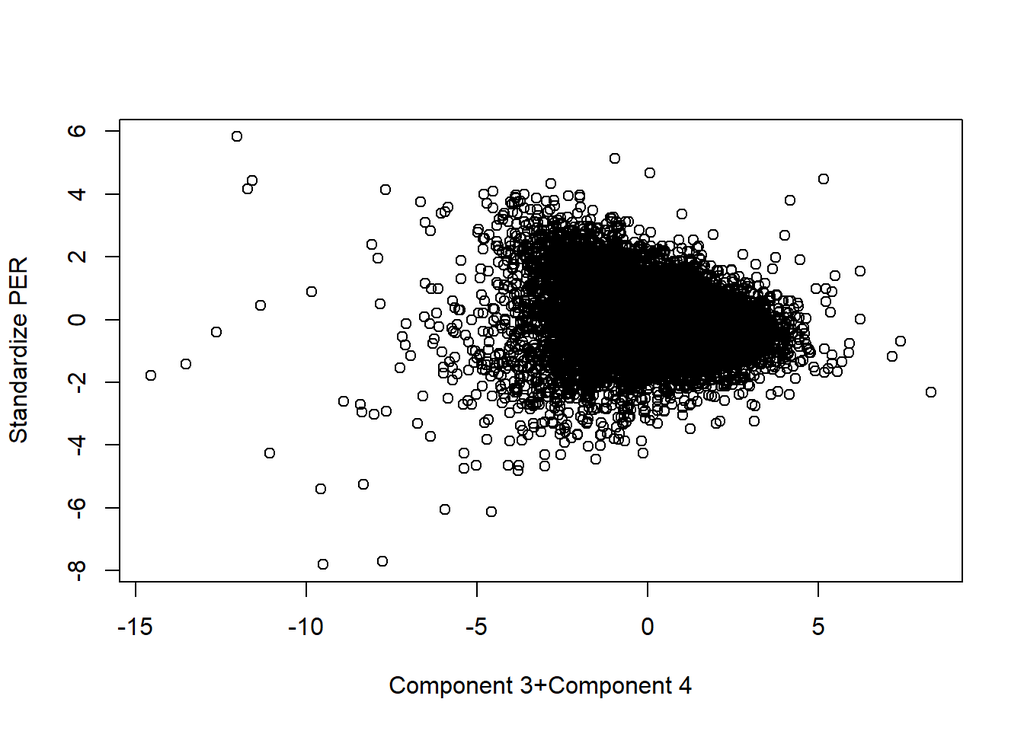

```r
plot(scores$Comp.3+scores$Comp.4,PER_norm,xlab='Component 3+Component 4',ylab='Standardize PER')
```

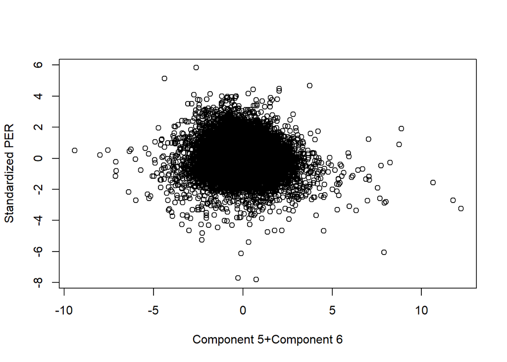

```r
plot(scores$Comp.5+scores$Comp.6,PER_norm,xlab='Component 5+Component 6',ylab='Standardized PER')
```

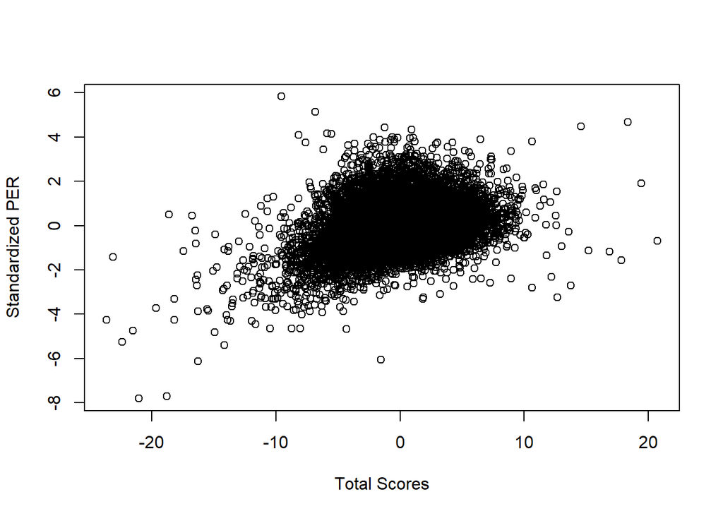

```r
plot(scores$total,PER_norm,xlab='Total Scores',ylab='Standardized PER')
```

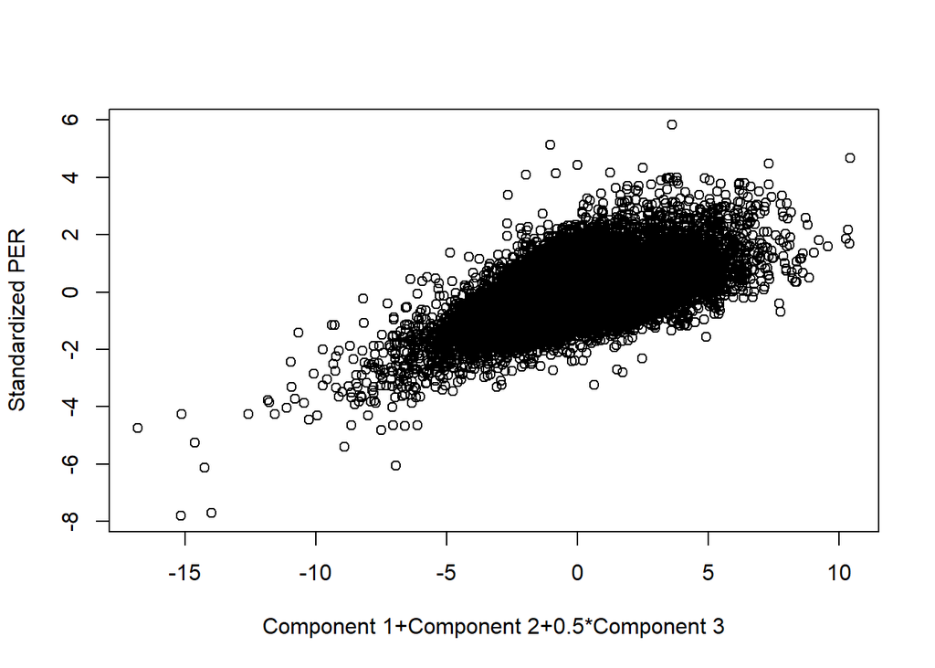

```r
plot(scores$Comp.1+scores$Comp.2+.5*scores$Comp.3,PER_norm,xlab='Component 1+Component 2+0.5*Component 3',ylab='Standardized PER')
```

```r
train=sample(c(1:nrow(all)),nrow(all)/2,replace=FALSE)
test=c(1:nrow(all))[-train]
standard_stats=lm(PER_norm[train]~quantitative_stats_norm[train,]+0)
summary(standard_stats)
```

```
##
## Call:
## lm(formula = PER_norm[train] ~ quantitative_stats_norm[train,
##     ] + 0)
##
## Residuals:
##      Min       1Q   Median       3Q      Max
## -2.99522 -0.16535 -0.00246  0.16059  2.08736
##
## Coefficients:
##                                             Estimate Std. Error t value
## quantitative_stats_norm[train, ]TS._norm   0.1460915  0.0071091  20.550
## quantitative_stats_norm[train, ]ORB._norm  0.1510650  0.0046027  32.821
## quantitative_stats_norm[train, ]DRB._norm  0.1458736  0.0045364  32.156
## quantitative_stats_norm[train, ]AST._norm  0.2944696  0.0044027  66.884
## quantitative_stats_norm[train, ]STL._norm  0.0774847  0.0036439  21.264
## quantitative_stats_norm[train, ]BLK._norm  0.0998566  0.0040055  24.930
## quantitative_stats_norm[train, ]USG._norm -0.2367291  0.0113727 -20.815
## quantitative_stats_norm[train, ]BPM_norm   0.2691807  0.0056500  47.643
## quantitative_stats_norm[train, ]X3P._norm  0.0146237  0.0034717   4.212
## quantitative_stats_norm[train, ]X2P._norm -0.0008162  0.0051761  -0.158
## quantitative_stats_norm[train, ]FT._norm   0.0281394  0.0036517   7.706
## quantitative_stats_norm[train, ]PPM_norm   0.7250760  0.0127899  56.691
##                                           Pr(>|t|)
## quantitative_stats_norm[train, ]TS._norm   < 2e-16 ***
## quantitative_stats_norm[train, ]ORB._norm  < 2e-16 ***
## quantitative_stats_norm[train, ]DRB._norm  < 2e-16 ***
## quantitative_stats_norm[train, ]AST._norm  < 2e-16 ***
## quantitative_stats_norm[train, ]STL._norm  < 2e-16 ***
## quantitative_stats_norm[train, ]BLK._norm  < 2e-16 ***
## quantitative_stats_norm[train, ]USG._norm  < 2e-16 ***
## quantitative_stats_norm[train, ]BPM_norm   < 2e-16 ***
## quantitative_stats_norm[train, ]X3P._norm 2.56e-05 ***
## quantitative_stats_norm[train, ]X2P._norm    0.875
## quantitative_stats_norm[train, ]FT._norm  1.47e-14 ***
## quantitative_stats_norm[train, ]PPM_norm   < 2e-16 ***
## ---
## Signif. codes:  0 '***' 0.001 '**' 0.01 '*' 0.05 '.' 0.1 ' ' 1
##
## Residual standard error: 0.257 on 7541 degrees of freedom
## Multiple R-squared:  0.9335, Adjusted R-squared:  0.9334
## F-statistic:  8820 on 12 and 7541 DF,  p-value: < 2.2e-16
```

```r
p1=lm(PER_norm[train]~all$Comp.1[train]+0)
p02=lm(PER_norm[train]~all$Comp.2[train]+0)
p2=lm(PER_norm[train]~all$Comp.1[train]+all$Comp.2[train]+0)
p3=lm(PER_norm[train]~all$Comp.1[train]+all$Comp.2[train]+all$Comp.3[train]+0)
p4=lm(PER_norm[train]~all$Comp.1[train]+all$Comp.2[train]+all$Comp.3[train]+all$Comp.4[train]+0)
p5=lm(PER_norm[train]~all$Comp.1[train]+all$Comp.2[train]+all$Comp.3[train]+all$Comp.4[train]+all$Comp.5[train]+0)
p6=lm(PER_norm[train]~all$Comp.1[train]+all$Comp.2[train]+all$Comp.3[train]+all$Comp.4[train]+all$Comp.5[train]+all$Comp.6[train]+0)
p7=lm(PER_norm[train]~all$Comp.1[train]+all$Comp.2[train]+all$Comp.3[train]+all$Comp.4[train]+all$Comp.5[train]+all$Comp.6[train]+all$Comp.7[train]+0)

summary(p1)
```

```
##
## Call:
## lm(formula = PER_norm[train] ~ all$Comp.1[train] + 0)
##
## Residuals:
##     Min      1Q  Median      3Q     Max
## -7.8074 -0.6063 -0.0141  0.5857  5.8036
##
## Coefficients:
##                    Estimate Std. Error t value Pr(>|t|)
## all$Comp.1[train] -0.004267   0.006487  -0.658    0.511
##
## Residual standard error: 0.9958 on 7552 degrees of freedom
## Multiple R-squared:  5.728e-05,  Adjusted R-squared:  -7.513e-05
## F-statistic: 0.4326 on 1 and 7552 DF,  p-value: 0.5107
```

```r
summary(p02)
```

```
##
## Call:
## lm(formula = PER_norm[train] ~ all$Comp.2[train] + 0)
##
## Residuals:
##      Min       1Q   Median       3Q      Max
## -3.03751 -0.23981 -0.01428  0.23201  2.30720
##
## Coefficients:
##                   Estimate Std. Error t value Pr(>|t|)
## all$Comp.2[train] 0.533017   0.002623   203.2   <2e-16 ***
## ---
## Signif. codes:  0 '***' 0.001 '**' 0.01 '*' 0.05 '.' 0.1 ' ' 1
##
## Residual standard error: 0.3915 on 7552 degrees of freedom
## Multiple R-squared:  0.8454, Adjusted R-squared:  0.8454
## F-statistic: 4.131e+04 on 1 and 7552 DF,  p-value: < 2.2e-16
```

```r
summary(p2)
```

```
##
## Call:
## lm(formula = PER_norm[train] ~ all$Comp.1[train] + all$Comp.2[train] +
##     0)
##
## Residuals:
##      Min       1Q   Median       3Q      Max
## -3.03359 -0.23969 -0.01371  0.23253  2.29041
##
## Coefficients:
##                    Estimate Std. Error t value Pr(>|t|)
## all$Comp.1[train] -0.006301   0.002550  -2.472   0.0135 *
## all$Comp.2[train]  0.533042   0.002622 203.321   <2e-16 ***
## ---
## Signif. codes:  0 '***' 0.001 '**' 0.01 '*' 0.05 '.' 0.1 ' ' 1
##
## Residual standard error: 0.3914 on 7551 degrees of freedom
## Multiple R-squared:  0.8456, Adjusted R-squared:  0.8455
## F-statistic: 2.067e+04 on 2 and 7551 DF,  p-value: < 2.2e-16
```

```r
summary(p3)
```

```
##
## Call:
## lm(formula = PER_norm[train] ~ all$Comp.1[train] + all$Comp.2[train] +
##     all$Comp.3[train] + 0)
##
## Residuals:
##      Min       1Q   Median       3Q      Max
## -2.74923 -0.23432 -0.01587  0.22819  2.25035
##
## Coefficients:
##                    Estimate Std. Error t value Pr(>|t|)
## all$Comp.1[train] -0.005655   0.002508  -2.255   0.0242 *
## all$Comp.2[train]  0.533221   0.002579 206.795   <2e-16 ***
## all$Comp.3[train] -0.058466   0.003653 -16.004   <2e-16 ***
## ---
## Signif. codes:  0 '***' 0.001 '**' 0.01 '*' 0.05 '.' 0.1 ' ' 1
##
## Residual standard error: 0.3849 on 7550 degrees of freedom
## Multiple R-squared:  0.8506, Adjusted R-squared:  0.8506
## F-statistic: 1.433e+04 on 3 and 7550 DF,  p-value: < 2.2e-16
```

```r
summary(p4)
```

```
##
## Call:
## lm(formula = PER_norm[train] ~ all$Comp.1[train] + all$Comp.2[train] +
##     all$Comp.3[train] + all$Comp.4[train] + 0)
##
## Residuals:
##     Min      1Q  Median      3Q     Max
## -4.1637 -0.1847 -0.0036  0.1841  1.9335
##
## Coefficients:
##                    Estimate Std. Error t value Pr(>|t|)
## all$Comp.1[train] -0.005557   0.002150  -2.584  0.00978 **
## all$Comp.2[train]  0.533689   0.002211 241.409  < 2e-16 ***
## all$Comp.3[train] -0.056197   0.003132 -17.940  < 2e-16 ***
## all$Comp.4[train] -0.181261   0.003474 -52.174  < 2e-16 ***
## ---
## Signif. codes:  0 '***' 0.001 '**' 0.01 '*' 0.05 '.' 0.1 ' ' 1
##
## Residual standard error: 0.33 on 7549 degrees of freedom
## Multiple R-squared:  0.8902, Adjusted R-squared:  0.8902
## F-statistic: 1.53e+04 on 4 and 7549 DF,  p-value: < 2.2e-16
```

```r
summary(p5)
```

```
##
## Call:
## lm(formula = PER_norm[train] ~ all$Comp.1[train] + all$Comp.2[train] +
##     all$Comp.3[train] + all$Comp.4[train] + all$Comp.5[train] +
##     0)
##
## Residuals:
##     Min      1Q  Median      3Q     Max
## -4.0248 -0.1841 -0.0053  0.1808  1.8007
##
## Coefficients:
##                    Estimate Std. Error t value Pr(>|t|)
## all$Comp.1[train] -0.005514   0.002121  -2.599  0.00936 **
## all$Comp.2[train]  0.533435   0.002181 244.570  < 2e-16 ***
## all$Comp.3[train] -0.056006   0.003090 -18.123  < 2e-16 ***
## all$Comp.4[train] -0.181717   0.003428 -53.015  < 2e-16 ***
## all$Comp.5[train] -0.058781   0.004077 -14.419  < 2e-16 ***
## ---
## Signif. codes:  0 '***' 0.001 '**' 0.01 '*' 0.05 '.' 0.1 ' ' 1
##
## Residual standard error: 0.3256 on 7548 degrees of freedom
## Multiple R-squared:  0.8932, Adjusted R-squared:  0.8931
## F-statistic: 1.262e+04 on 5 and 7548 DF,  p-value: < 2.2e-16
```

```r
summary(p6)
```

```
##
## Call:
## lm(formula = PER_norm[train] ~ all$Comp.1[train] + all$Comp.2[train] +
##     all$Comp.3[train] + all$Comp.4[train] + all$Comp.5[train] +
##     all$Comp.6[train] + 0)
##
## Residuals:
##     Min      1Q  Median      3Q     Max
## -3.9209 -0.1836 -0.0032  0.1801  1.7480
##
## Coefficients:
##                    Estimate Std. Error t value Pr(>|t|)
## all$Comp.1[train] -0.005297   0.002087  -2.538   0.0112 *
## all$Comp.2[train]  0.533680   0.002146 248.719   <2e-16 ***
## all$Comp.3[train] -0.055613   0.003040 -18.292   <2e-16 ***
## all$Comp.4[train] -0.182412   0.003372 -54.092   <2e-16 ***
## all$Comp.5[train] -0.058084   0.004011 -14.483   <2e-16 ***
## all$Comp.6[train] -0.069061   0.004346 -15.889   <2e-16 ***
## ---
## Signif. codes:  0 '***' 0.001 '**' 0.01 '*' 0.05 '.' 0.1 ' ' 1
##
## Residual standard error: 0.3203 on 7547 degrees of freedom
## Multiple R-squared:  0.8966, Adjusted R-squared:  0.8965
## F-statistic: 1.091e+04 on 6 and 7547 DF,  p-value: < 2.2e-16
```

```r
summary(p7)
```

```
##
## Call:
## lm(formula = PER_norm[train] ~ all$Comp.1[train] + all$Comp.2[train] +
##     all$Comp.3[train] + all$Comp.4[train] + all$Comp.5[train] +
##     all$Comp.6[train] + all$Comp.7[train] + 0)
##
## Residuals:
##     Min      1Q  Median      3Q     Max
## -3.2597 -0.1747 -0.0008  0.1736  1.9747
##
## Coefficients:
##                    Estimate Std. Error t value Pr(>|t|)
## all$Comp.1[train] -0.004686   0.001998  -2.345   0.0191 *
## all$Comp.2[train]  0.534235   0.002055 259.998   <2e-16 ***
## all$Comp.3[train] -0.055693   0.002911 -19.130   <2e-16 ***
## all$Comp.4[train] -0.182785   0.003229 -56.605   <2e-16 ***
## all$Comp.5[train] -0.057458   0.003840 -14.961   <2e-16 ***
## all$Comp.6[train] -0.070115   0.004162 -16.846   <2e-16 ***
## all$Comp.7[train] -0.124322   0.004751 -26.168   <2e-16 ***
## ---
## Signif. codes:  0 '***' 0.001 '**' 0.01 '*' 0.05 '.' 0.1 ' ' 1
##
## Residual standard error: 0.3067 on 7546 degrees of freedom
## Multiple R-squared:  0.9052, Adjusted R-squared:  0.9051
## F-statistic: 1.03e+04 on 7 and 7546 DF,  p-value: < 2.2e-16
```